# MotifRegressR

Follow these commands to correctly install the package:

```r
if (!requireNamespace("devtools", quietly = TRUE)) {
  install.packages("devtools")
}
library(devtools)

devtools::install_github("https://github.com/LeonardoNossa/MotifRegressR")
```

```r
library(MotifRegressR)
```

## Description

MotifRegressR allows its users to perform DNA motifs regression in the context of gene expression studies, allowing the investigation of the most impactful motifs over different samples.

This is done by integrating gene upstream sequences (promoters) with Position Weight Matrices (PWMs) of the chosen organism. By sliding the PWMs over each upstream sequence, we assign different scores to each gene, representing the binding affinities of the motif in that region. Each gene promoter will be assigned the maximum score. This allows us to build the matrix of scores S.

Users can import PFMs from JASPAR, using the taxon ID of that species or custom sources (via a MEME file) and obtain the upstream sequences by proving a .gff and a FASTA file as input.

Users can also upload gene expression compendia containing gene expression levels across different conditions. If the IDs associated to each condition allow it, metadata can be retrieved from ENA browser to obtain more information regarding the samples.

MotifRegressR then performs regression analysis and determines the most impactful motifs for the different tested conditions. Downstream steps, mainly represented by visualization functions finally help the user in the sense-making steps of the analyses.

Below you find a visual representation of the project pipeline. If you are part of the University of Milan, you can view it by clicking the following link and entering your credentials.

[Microsoft Whiteboard Pipeline](https://unimi2013-my.sharepoint.com/:wb:/g/personal/marco_cominelli_studenti_unimi_it/EZApUGSaatFPlyUGVJopINMBtisiIJ_IU2fPwyi4fezndQ?e=mzdgal)

## Pipeline for the users in R

Here below you can find the commands of the pipeline with examples and explanations of the different functions. In the examples, we will use smaller portions of the typical data you would provide. This is done to speed up processing and give an overall idea on how the package works. All of the results you will see below are done using E.coli data

```r
set.seed(123)
```

### PFM_loader

The first step is to upload the Position Frequency Matrices (PFMs) with the specific function. You can load PFMs either from a local file in MEME format or by specifying a taxon ID to retrieve motifs from JASPAR database.

In the following example we are loading the first ten motifs from the local file `SwissRegulon_e_coli.meme` in the `extdata` directory. In order to speed up downstream steps, we will only take the first ten PFMs.

```r
path_PFM <- system.file("extdata/E.coli", "SwissRegulon_e_coli.meme", package = "MotifRegressR")
PFMs <- PFM_loader(path = path_PFM, tax_id = NULL)
PFMs_10 <- PFMs[1:10]
```

```
#> $`ArgP_14-0`
#>       A    C    G    T
#> 1  1.00 0.00 0.00 0.00
#> 2  0.00 0.00 0.00 1.00
#> 3  0.00 0.00 0.00 1.00
#> 4  0.00 0.00 0.50 0.50
#> 5  0.75 0.00 0.00 0.25
#> 6  0.25 0.50 0.00 0.25
#> 7  0.25 0.75 0.00 0.00
#> 8  0.75 0.00 0.00 0.25
#> 9  0.75 0.25 0.00 0.00
#> 10 0.25 0.00 0.25 0.50
#> 11 1.00 0.00 0.00 0.00
#> 12 0.25 0.25 0.00 0.50
#> 13 0.00 0.25 0.50 0.25
```

### retrieve_logos

The user can use the function `retrieve_logos` to retrieve the genomic logos of the motifs contained in the PFM list. The function returns a named list of logos plots, named as the motifs.

```r
logos <- retrieve_logos(PFMs = PFMs_10)
```

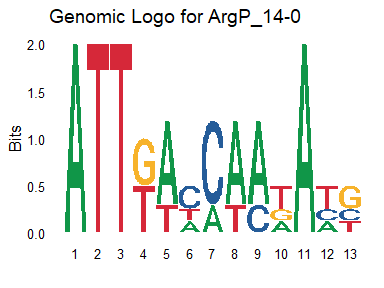

### retrieve_frequencies

By using this function the user can retrieve the nucleotide frequencies of an organism, starting from its genomic sequence, provided in FASTA format.

```r
path_fasta <- system.file("extdata/E.coli", "GCF_000005845.2_ASM584v2_genomic.fna", package = "MotifRegressR")
background <- retrieve_frequencies(fasta = path_fasta)
```

```
#>         A         C         G         T
#> 0.2461930 0.2542394 0.2536677 0.2459000
```

### PFM2PWM

The next step is to convert all your PFMs into Position Weight Matrices (PWMs). The user can provide the genomic background computed in the previous section, or simply assume an uniform background of 0.25 for each nucleotide.

```r
PWMs <- PFM2PWM(PFMs = PFMs_10, background = background)
```

```
#> $`ArgP_14-0`
#>              A           C           G           T
#> 1   1.97991041 -4.72469947 -4.72145122 -4.67658307
#> 2  -4.72469947 -4.72145122 -4.67658307  1.97991041
#> 3  -4.72145122 -4.67658307 -4.67830107  1.93351201
#> 4  -4.67658307 -4.67830107  0.94772587  0.95097412
#> 5   1.56962644 -4.72469947 -4.72145122  0.02385665
#> 6  -0.02425975  0.95097412 -4.67658307  0.02213864
#> 7  -0.02101151  1.57134444 -4.67830107 -4.72469947
#> 8   1.57134444 -4.67830107 -4.72469947 -0.02101151
#> 9   1.56962644 -0.02425975 -4.72145122 -4.67658307
#> 10 -0.02425975 -4.72145122  0.02385665  0.99412427
#> 11  1.93676026 -4.67658307 -4.67830107 -4.72469947
#> 12  0.02385665  0.02213864 -4.72469947  0.95097412
#> 13 -4.67830107 -0.02425975  0.95097412  0.02385665
```

### get_sequences

The user will then use the `get_sequences` function to extract DNA sequences, corresponding to regions upstream to each gene (promoters). The function uses regions corresponding to genes defined in a GFF file and retrieves the corresponding sequences from a FASTA file. Given that we are working with E. coli, we set the `species` parameter to “Bacteria”. The `upstream` value is set to 300bp by default, but can be specified by the user.

```r
path_gff <- system.file("extdata/E.coli", "GCF_000005845.2_ASM584v2_genomic.gff", package = "MotifRegressR")
path_fasta <- system.file("extdata/E.coli", "GCF_000005845.2_ASM584v2_genomic.fna", package = "MotifRegressR")

dataSeq <- get_sequences(gff = path_gff, fasta = path_fasta, species = "Bacteria")
dataSeq_500 <- dataSeq[1:500,]
```

```
#> [1] "Chr: NC_000913.3"
#> [1] "Sequence: TGTGTGGATTAAAAAAAGAGTGTCT...GACCAAAGGTAACGAGGTAACAACCA"
```

The function returns a matrix of size N x 2, where N is the number of genes.

- The first column “Chr” contains the chromosome ID to which the sequence belongs
- The second column “Sequence” contains the actual sequence
- The row names of the matrix correspond to the gene IDs

### scorer

Now that the user obtained PWMs and the upstream gene sequences, the Scores matrix S can be computed. MotifRegressR evaluates how well each sequence aligns with the position weight matrices.

This process involves scoring upstream sequences of each gene, by sliding the PWMs on them. The final score of a Motif on a gene is the maximum among all the scores obtained during the sliding (the most reliable binding site will correspond to the highest score).

The user can decide whether or not to also consider the reverse complement of the sequences. This is specified by the `both` parameter. If both strands are considered, two matrices are computed and the final score will be the maximum between the two strands (i.e. the most reliable binding site).

Considering both strands should allow the integration of more information and the production of more reliable results, since we are considering more putative binding sites.

Given the computational burden of this step, parallelization is employed. You can modify the number of cores to use with the parameter `workers`.

```r
S <- scorer(PWMs = PWMs, dataSeq = dataSeq_500, workers = 5, both = TRUE)
```

```
#> [1] "Scores for gene b0002: "
#>   Ada_28-0  AgaR_25-2  AraC_19-8  AraC_19-9  ArcA_28-0 ArcA_28-37  ArgP_14-0
#>   8.701891   6.499455   3.918389   5.439689   9.305293   6.541565  12.894345
#>  ArgR_26-5  CpxR_14-3  CpxR_14-8
#>   7.498554   7.482297  11.252154
```

The function returns a matrix of size N x M, where N is the number of genes (one upstream sequence for each gene) and M is the number of motifs.

- The row names will be the gene IDs
- The column names will be the names of the motifs

Each entry will be the best score assigned to a motif in a particular gene.

### compendium_loader

The user can then load gene expressions data. This function loads data from a specified file path and returns a data frame. It uses `read.table()` to read the file, assuming a comma-separated values (CSV) format.

```r
path_compendium <- system.file("extdata/E.coli", "compendium.csv", package = "MotifRegressR")
compendium <- compendium_loader(path = path_compendium, sep = ",", header = TRUE, row.names = 1)
compendium_500 <- compendium[1:500, 1:10]
```

```
#> [1] "Gene expression values for gene b0002:"
#>       DRR091867 DRR091875 DRR091882 DRR100424 DRR100428 ERR1025366 ERR1370908
#> b0002   23.1442  16.59721  46.24706  325.5983  148.9433   3.063589   2.751549
#>       ERR1370919 ERR1399586 ERR1399594
#> b0002   1.488272   58.28788   12.34488
```

The shape of the compendium data frame should be N x K, where N is the number of genes and K is the number of samples.

- The row names will be the gene IDs
- The column names will be sample IDs (or generic sample names)

Each entry will be the gene expression level of a gene in a sample.

### retrieve_metadata

If the compendium sample IDs allow it, the user can retrieve metadata about the samples using this function that looks for the sample IDs and retrieve information from the ENA browser.

```r
metadata <- retrieve_metadata(compendium = compendium_500)
```

```
#> [1] "Metadata for sample DRR091867: "
#> [1] "run_accession: DRR091867"
#> [1] "secondary_study_accession: DRP005030"
#> [1] "sample_accession: SAMD00079815"
#> [1] "secondary_sample_accession: DRS093526"
#> [1] "experiment_accession: DRX085437"
#> [1] "study_accession: PRJDB5742"
#> [1] "submission_accession: DRA005771"
#> [1] "tax_id: 511145"
#> [1] "scientific_name: Escherichia coli str. K-12 substr. MG1655"
#> [1] "instrument_model: Illumina MiSeq"
#> [1] "library_name: "
#> [1] "library_layout: PAIRED"
#> [1] "library_strategy: RNA-Seq"
#> [1] "library_source: TRANSCRIPTOMIC"
#> [1] "library_selection: cDNA"
#> [1] "base_count: 282043925"
#> [1] "center_name: TIT-BB"
#> [1] "first_public: 2019-05-02"
#> [1] "last_updated: 2019-05-02"
#> [1] "experiment_title: Illumina MiSeq paire ... ncing of SAMD00079815"
#> [1] "study_title: Growth inhibition af ... iminate RNA cleavage."
#> [1] "study_alias: DRP005030"
#> [1] "experiment_alias: DRX085437"
#> [1] "run_alias: DRR091867"
#> [1] "sample_alias: SAMD00079815"
#> [1] "sample_title: Control_rep1-1"
#> [1] "first_created: 2019-05-02"
```

The function returns a data frame of size (at most) K x 27, where K is the number of samples If metadata for some samples cannot be retrieved the metadata data frame will have less than K rows The columns contain selected features of each sample.

### plot_dimensionality_reduction

MotifRegressR allows the user to visualize the samples in the compendium in a 2D space, by applying dimensionality reduction techniques. Results are visualized using `plotly`, also integrating metadata information, if possible. If metadata are present, the user can also decide to color points by a certain feature contained in the metadata. Here we color points by “tax_id”.

The function supports different dimensionality reduction techniques. Available dimensionality reduction techniques in this first release are:

- PCA
- MDS
- t-SNE
- UMAP

Here we use the PCA method.

```r
plot_dimensionality_reduction(compendium = compendium_500, metadata = metadata,
                              color_by = "tax_id", method = "PCA")
```

[interactive chart not shown]

### principal_comps [OPTIONAL STEP]

This function has been thought in order to reduce the dimensionality of the gene expression compendium. By using `principal_comps` function, the user is allowed to find the optimal number of components that explain the desired % of variance. The function takes as input a matrix and returns a matrix representing the coordinates of the points in the PCA space. Even though the function has been implemented to be used on the columns of the compendium, the user can actually use it also on the rows of both compendium and S matrix.

The user can choose the % of explained variance used to determine the right number of components (`explained_var` parameter), the axis on which to perform PCA (`axis = 1` for rows, `axis = 2` for columns) and finally can also choose whether or not to scale the data before performing the PCA (`scale` parameter).

This step is thought to be optional and obviously reduces interpretability of the results.

```r
PC <- principal_comps(matrix = as.matrix(compendium_500),
                      explained_var = 95, axis = 2, scale = TRUE)
```

### table_first_genes & filter [OPTIONAL STEP]

If the organism is prokaryotic, proper filtering has to be made in order to only consider first genes of each operon. The idea is that taking upstream sequences of genes that are in the middle of the operon, won’t add information to the analysis, and will likely only introduce bias in the results (if we score the upstream sequences of a gene that is in the middle of an operon, we are not getting its promoter, but likely the gene before).

The idea is to integrate information coming from the files you find below in order to build a table containing only the first genes of each operon:

- `TUSet.tsv` file contains information regarding the operons, allowing us to understand the first gene of each of the operons
- `511145_protein_info_v12_0.txt` file contains protein annotation, including correspondance of gene ID to gene name.

```r
path_TSV <- system.file("extdata/E.coli", "TUSet.tsv", package = "MotifRegressR")
path_PRO <- system.file("extdata/E.coli", "511145_protein_info_v12_0.txt", package = "MotifRegressR")

first_genes <- table_first_genes(tsv = path_TSV, pro = path_PRO)
```

```
#>   Gene_ID Gene_Name
#> 1   b0001      thrL
#> 5   b0005      yaaX
#> 6   b0006      yaaA
#> 7   b0007      yaaJ
#> 8   b0008      talB
```

The output of the function will be a matrix of size N x 2, where N is the number of genes. For each gene ID we will have its corresponding gene name.

A filtering step can then be performed on the S matrix and the compendium to only retain the first genes of each operon. This is done using the `filter` function. During the filtering step, GeneIDs are replaced by the actual gene names for better readability of the results.

```r
S <- filter(to_filter = S, to_keep = first_genes)
compendium_500 <- filter(to_filter = compendium_500, to_keep = first_genes)
```

### regressor and retrieve_params_list

Once both the S matrix and the gene expression compendium are retrieved, the user can perform the regression step. In the context of regression, the Score matrix S will be the predictor matrix X, while single columns of the compendium will be the response variable y.

After the fitting of the models, the idea is to extract values representing the importance of a certain motif (a column of the S matrix) in a certain condition.

Please, remember that here only a small portion of data is used as examples.

`regressor` function trains multiple regression models on the Score matrix and compendium data, over the selected number of columns.

It filters the rows to retain only the common ones between the scores and the compendium before training the models. The function allows to train various types of regression models based on the specified regression types and their respective parameters.

Supported regression in this first release are:

- Simple linear regression: “LM”
- Partial Least Squares regression: “PLS”
- K-nearest neighbors regression: “KNN”
- Random Forest regression: “RF”
- Support Vector Machines regression: “SVM”
- Randomized Stability Lasso regression: “Randomized_lasso”
- Two-way Orthogonal PLS regression: “O2PLS”

The user is allowed to specify regression parameters, or leave them as default, by using the `retrieve_params_list` function. The function returns a list of arguments that MUST be passed as an argument of `regressor`.

In this case we will use 5 regression types (“LM”, “RF”, “SVM”, “PLS”, “O2PLS”), over 5 conditions in the compendium. Parameters are left as default.

```r
regression_params_list <- retrieve_params_list()
regressions <- c("LM", "RF", "SVM","PLS","O2PLS")
conditions <- c(1,2,3,4,5)

models <- regressor(scores = S, compendium = compendium_500,
                    conditions = conditions, regression_type = regressions,
                    regression_params_list = regression_params_list)
```

The output of the function will be a named list, where each element is a list, corresponding to a specific regression type over all tested conditions.

### Diagnostic plots: plot_

The user has access to plotting function for each of the implemented regression models:

- plot_LM
- plot_KNN
- plot_SVM
- plot_PLS
- plot_O2PLS
- plot_RANDLASSO
- plot_RF

Each function returns a named list containing the plots and the data used to generate them. In this example we will visualize plots for a PLS model.

```r
plot_list <- plot_PLS(models$PLS$DRR091867)
```

```r
plot_list$Component_2
```

[interactive chart not shown]

### models2dataframe

With this function you can convert the models list, obtained as output of `regressor` into data frames, containing the top `k` important motifs for each model. If the extraction of the motifs require a filtering step (significance of beta coefficients for “LM”) , this is automatically taken care of.

```r
dfs <- models2dataframe(regression_list = models, alpha = 0.05)
```

The output of the function will be a named list of data frames, each of them corresponding to a different regression type. Each data frame contains the top `k` most important motifs, the condition they refer to (`k` motifs per condition) and their importance value.

```
#> $PLS
#>        motifs conditions       coef
#> 1    Ada_28-0  DRR091867  10.065532
#> 2   CpxR_14-3  DRR091867   7.317114
#> 3   ArgP_14-0  DRR091867  -5.423030
#> 4   CpxR_14-8  DRR091867   3.117912
#> 5  ArcA_28-37  DRR091867  -3.002265
#> 6    Ada_28-0  DRR091875   3.496594
#> 7   ArgP_14-0  DRR091875  -2.891362
#> 8   AgaR_25-2  DRR091875  -2.787657
#> 9   ArgR_26-5  DRR091875  -2.569285
#> 10  CpxR_14-8  DRR091875   2.388152
#> 11  AraC_19-9  DRR091882   8.264119
#> 12  AgaR_25-2  DRR091882  -6.637369
#> 13  CpxR_14-8  DRR091882   5.310702
#> 14   Ada_28-0  DRR091882   4.952808
#> 15  CpxR_14-3  DRR091882  -4.398043
#> 16   Ada_28-0  DRR100424  84.224802
#> 17  ArgR_26-5  DRR100424 -49.524612
#> 18  AraC_19-8  DRR100424 -38.724407
#> 19  CpxR_14-3  DRR100424  38.431667
#> 20 ArcA_28-37  DRR100424  37.896718
#> 21  CpxR_14-8  DRR100428  36.914673
#> 22 ArcA_28-37  DRR100428  36.735007
#> 23   Ada_28-0  DRR100428  35.051665
#> 24  CpxR_14-3  DRR100428  34.331786
#> 25  ArcA_28-0  DRR100428  28.225609
```

### plot_digraph

This function allows the user to visualize relationships between motifs and conditions in a bipartite graph. In order to realize the plot, the function needs the names of the motifs and one of the sublists obtained using `models2dataframe` function.

The nodes represent conditions (diamonds) and motifs (squares). The edges connect a motif to a condition if that motif is among the top `k` motifs in that condition for that regression model. Edges are colored proportionally to their Importance value.

The graph is rendered interactively using `plotly`. Here we chose PLS as example.

```r
plot_digraph(motif_names = colnames(S), edges_sublist = dfs["PLS"])
```

[interactive chart not shown]

### plot_clustermap

In order to visualize motifs exhibiting similar patterns across conditions (and most similar conditions as well), the user can use this function to build a clustermap. The function takes as input a sublist coming from `models2dataframe`. Clustering methods and metrics can also be specified for both rows and columns.

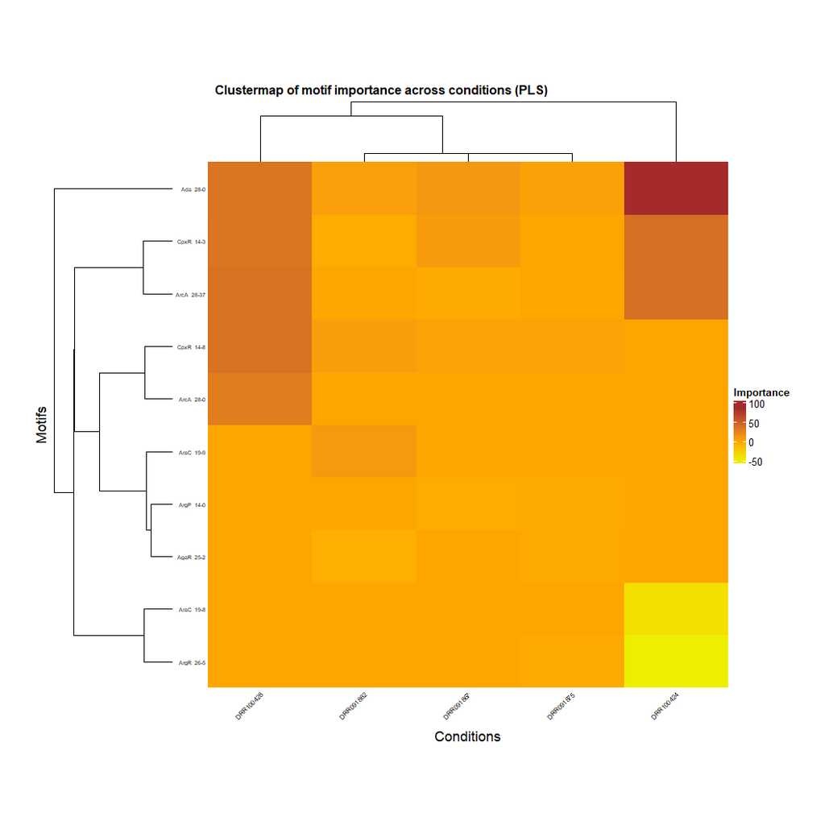

```r
plot_clustermap(df_sublist = dfs["PLS"],
                distance = c("euclidean", "euclidean"),
                method = c("single", "single"))
```

### consensus_motifs

Motif regression is no easy task and single regression models are not always able to fully describe gene expression using Motif Scores. The strength of MotifRegressR lies in the number of regression types that can be used by the user. That is why `consensus_motifs` function has been implemented.

The function takes as input the output of `models2dataframe` and builds a consensus of motifs to explore the conservation of motifs across different regression types `by_regressor = TRUE` or across conditions `by_regressor = FALSE`.

- In the first case (`by_regressor = TRUE`) we are looking at how many times a motif appears among the top `k` motifs in that condition, across all regression types.
- In the second case `by_regressor = FALSE`) we are looking at how many times a motif appears among the top `k` motifs in that regression type, across all conditions.

```r
consensus <- consensus_motifs(df_list = dfs, by_regressor = TRUE)
```

### consensus_motifs_heatmap

The user can then visualize results in the form of a heatmap: the heatmap will show the conservation of motifs across conditions or regression types, according to `by_regressor` parameter.

In this case we are looking at motifs conservation across regression types. Darker cells will represent motifs that appear among the top `k` motifs in that condition.

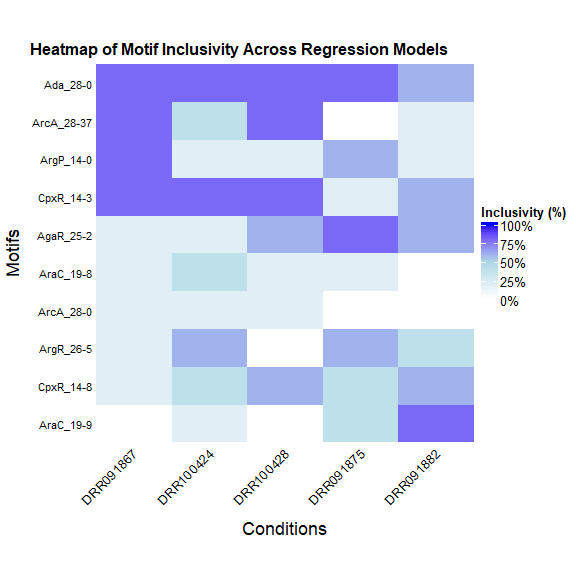

```r
consensus_motifs_heatmap(consensus_output = consensus)
```

### consensus_fisher_test

The statistical significance of the consensus (association between motifs and conditions) can be validated using a Fisher’s Exact test. Due to the sparsity of the matrix, results have to be interpreted carefully, but give a nice insight on the statistical significance of the observed conservation of motifs.

The function has been thought to assess association between motifs and conditions. `num_of_regressions` parameters should be the length of `models2dataframe` output (which is a list, with one element per regression type).

```r
consensus_fisher_test(consensus = consensus,
                      num_of_regressions = length(dfs),
                      alpha = 0.05)
```

```
#> p-value (0.6427) >= than α (0.05) [FAIL TO REJECT H0]
#>
#>  Fisher's Exact Test for Count Data with simulated p-value (based on
#>  10000 replicates)
#>
#> data:  matrix
#> p-value = 0.6427
#> alternative hypothesis: two.sided
```

The results here appears to be non-significant, likely for the reduced number of motifs, genes and conditions we chose for the analysis.

## Web interface app

A shiny Web application has also been implemented to allow people not familiar with R to use MotifRegressR functionalities. In order to use it, run the `app.R` script and read the tutorial!